# Welcome to Jiaxuan's Terminal.

#### ggtree自带的geom图层美化

以下就是`ggtree`自带的图层（我删去了一部分，完整的看帮助文档），还是需要什么了解什么吧。

| 层 | 描述 |
| --- | --- |
| geom_cladelabel | 使用条形和文本标签注释分支 |
| geom_hilight | 突出显示带矩形的分支 |
| geom_label2 | geom_label的修改版本，支持子集 |
| geom_nodelab | 节点标签的图层，可以是文本或图像 |
| geom_nodepoint | 使用符号点注释内部节点 |
| geom_point2 | geom_point的修改版本，支持子集 |
| geom_rootpoint | 用符号点注释根节点 |
| geom_text2 | geom_text的修改版本，支持子集 |
| geom_tiplab | 尖端标签层，可以是文本或图像 |
| geom_tippoint | 用符号点注释外部节点 |
| geom_tree | 树结构层，支持多种布局 |

我个人比较感兴趣的

`geom_cladelabel`,`geom_hilight`,`geom_tiplab`,这些geom图层。所以主要还是讲这些。

#### 显示树尺度（纯copy帮助文档）

要显示树比例，用户可以使用`geom_treescale()`图层。

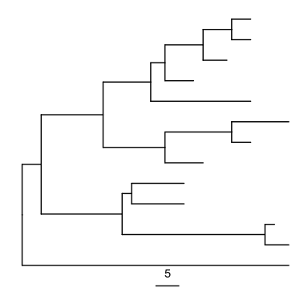

```r
ggtree(tree) + geom_treescale()
```

#### 显示节点/提示（纯copy帮助文档）

显示所有树的内部节点和提示，😉可以通过使用添加点的层来完成`geom_nodepoint`，`geom_tippoint`或者`geom_point`。

```
ggtree(tree) + geom_point(aes(shape=isTip, color=isTip), size=3)
```

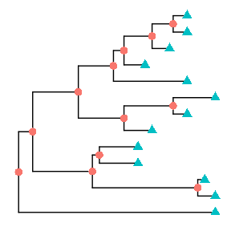

#### 显示标签(纯copy帮助文档)

用户可以同时使用`geom_text`或`geom_label`显示节点（如果可用）和提示标签，或`geom_tiplab`仅显示提示标签：

```
p + geom_tiplab(size=3, color="purple")
```

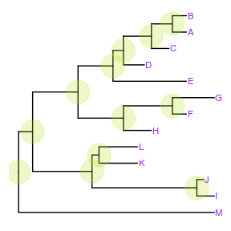

### 细节美化

进化树的细节美化主要依靠的是节点（*node*）这个参数，这个参数也是我之前已知没有理解的点。后来才发现这个*node*其实就是进化树上的**分枝点**。

如下图：

[figure not shown]

这样我们知道了*node*值就可以知道我们修改那些进化树的分支。

#### 获取NODE参数

所以在进行细节上的美化之前，我们一定要知道所需要美化的分枝所在的位置（*node*）。获得*node*方法：

1. 用以下命令绘制图形，看图形得知node

```r
ggtree(tree) + geom_text2(aes(subset=!isTip, label=node), hjust=-.3) + geom_tiplab()
```

2. 用以下命令得知，所关注的node位置，毕竟样本太多的时候，眼睛是看不过来的。

```r
MRCA(tree, tip=c('A', 'E'))#这里的A和E就是所关注的样本名称
```

3. 用`viewClade`查看分枝

```r
viewClade(p+geom_tiplab(), node=21)
```

#### geom图层美化分枝

知道了我们需要美化的分枝的node值，就可以进行美化

```r
tree <- groupClade(tree, .node=44)
ggtree(tree, aes(color=group, linetype=group))
```

我们也可规定多个节点

```r
tree <- groupClade(tree, .node=c(44, 47))
ggtree(tree, aes(color=group, linetype=group)) + geom_tiplab(aes(subset=(group==2)))
```

[figure not shown]

#### groupOTU美化端点

刚刚是关于分枝点（*node*）的美化，其实也有参数是进行树图最末端的端点进行美化的。端点就比较好理解，就是我们的样本名称。

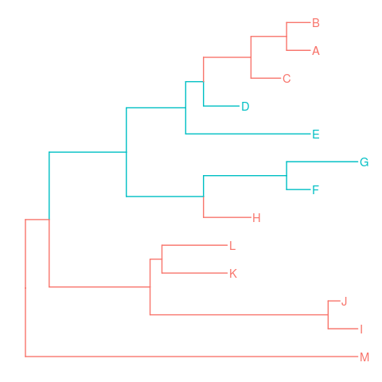

```r
tree <- groupOTU(tree, .node=c("D", "E", "F", "G"))#DDFG是样本名称
ggtree(tree, aes(color=group)) + geom_tiplab()
```

#### 高亮分枝

`geom_hilight`对关注的区域进行高亮显示，`scaleClade`对关注区域进行扩大或者缩小。

```
ggtree(tree) %>% scaleClade(44, scale=0.3) + geom_hilight(44, "steelblue")
```

[figure not shown]

#### 其他参数

用`rotate`旋转树图，用`flip`函数翻转两个选定的分支。

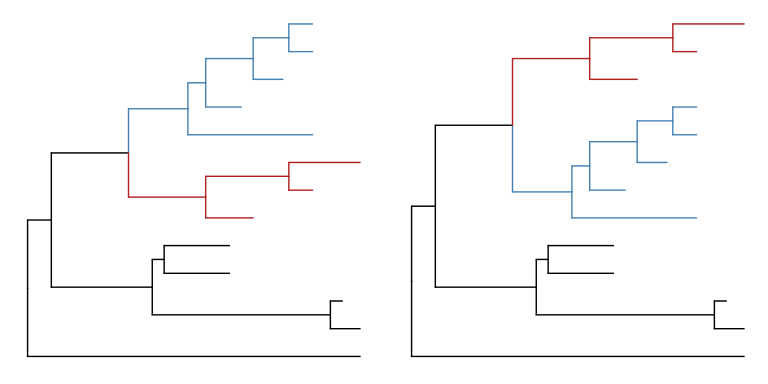

到此，我也算完成对`ggtree`的初步了解。完结撒花。

评论

[LICENSE: CC-BY-NC 4.0协议](https://creativecommons.org/licenses/by-nc-sa/4.0/deed.zh)

© 本站内容受CC-BY-NC 4.0协议保护,著作权归作者所有。商业转载请联系作者获得授权，非商业转载请注明出处。这篇文章创建在 **2019-07-10** , 内容的正确性和时效性请自行评估.